# Table of content

## 4.b) Bagging

Bagging is a technique to sampling training set with replacement. Most of time, the bagging method extract only 67% observations of the total. The rest of 32% will never appear in training which could left to be the testing set.

Here i use 6 algorithms using Bagging method to train the model and using the test set to see its final performance.  
Decision Tree, SVC (rbf), Logistic Regression, Random Forest, K-NN, Gussian Naive Bayes

```
------------------------------------------------------------------------------
Using classfier  DecisionTreeClassifier :

Confusion Matrix Scores:
             precision    recall  f1-score   support

     Normal       0.91      0.99      0.95        94
      Fraud       0.99      0.91      0.95       103

avg / total       0.95      0.95      0.95       197



Apply the best parameter to the test set and the result is:
```

```
^^^^^^^^^^^^^^^^^^^^^^^^^^^^^^^^^^^^^^^^^^^^^^^^^^^^^^^^^^^^^^^^^^^^^^^^^^^^^^



------------------------------------------------------------------------------
Using classfier  SVC :

Confusion Matrix Scores:
             precision    recall  f1-score   support

     Normal       0.91      0.98      0.94        94
      Fraud       0.98      0.91      0.94       103

avg / total       0.95      0.94      0.94       197



Apply the best parameter to the test set and the result is:
```

```
^^^^^^^^^^^^^^^^^^^^^^^^^^^^^^^^^^^^^^^^^^^^^^^^^^^^^^^^^^^^^^^^^^^^^^^^^^^^^^



------------------------------------------------------------------------------
Using classfier  LogisticRegression :

Confusion Matrix Scores:
             precision    recall  f1-score   support

     Normal       0.91      0.98      0.94        94
      Fraud       0.98      0.91      0.94       103

avg / total       0.95      0.94      0.94       197



Apply the best parameter to the test set and the result is:
```

```
^^^^^^^^^^^^^^^^^^^^^^^^^^^^^^^^^^^^^^^^^^^^^^^^^^^^^^^^^^^^^^^^^^^^^^^^^^^^^^



------------------------------------------------------------------------------
Using classfier  RandomForestClassifier :

Confusion Matrix Scores:
             precision    recall  f1-score   support

     Normal       0.91      1.00      0.95        94
      Fraud       1.00      0.91      0.95       103

avg / total       0.96      0.95      0.95       197



Apply the best parameter to the test set and the result is:
```

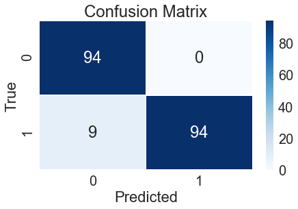

```
^^^^^^^^^^^^^^^^^^^^^^^^^^^^^^^^^^^^^^^^^^^^^^^^^^^^^^^^^^^^^^^^^^^^^^^^^^^^^^



------------------------------------------------------------------------------
Using classfier  KNeighborsClassifier :

Confusion Matrix Scores:
             precision    recall  f1-score   support

     Normal       0.92      0.96      0.94        94
      Fraud       0.96      0.92      0.94       103

avg / total       0.94      0.94      0.94       197



Apply the best parameter to the test set and the result is:
```

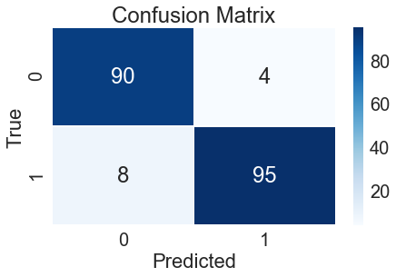

```
^^^^^^^^^^^^^^^^^^^^^^^^^^^^^^^^^^^^^^^^^^^^^^^^^^^^^^^^^^^^^^^^^^^^^^^^^^^^^^



------------------------------------------------------------------------------
Using classfier  GaussianNB :

Confusion Matrix Scores:
             precision    recall  f1-score   support

     Normal       0.88      0.97      0.92        94
      Fraud       0.97      0.88      0.92       103

avg / total       0.93      0.92      0.92       197



Apply the best parameter to the test set and the result is:
```

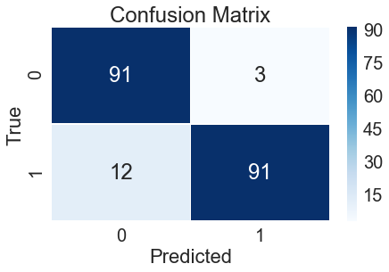

```
^^^^^^^^^^^^^^^^^^^^^^^^^^^^^^^^^^^^^^^^^^^^^^^^^^^^^^^^^^^^^^^^^^^^^^^^^^^^^^
```

## 4.c) Pasting

Back to top  
Pating is same as Bagging but the sampling is without replacement.

```
------------------------------------------------------------------------------
Using classfier DecisionTreeClassifier :

Confusion Matrix Scores:
             precision    recall  f1-score   support

     Normal       0.90      0.97      0.93        94
      Fraud       0.97      0.90      0.93       103

avg / total       0.94      0.93      0.93       197



Apply the best parameter to the test set and the result is:
```

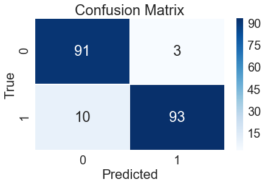

```
^^^^^^^^^^^^^^^^^^^^^^^^^^^^^^^^^^^^^^^^^^^^^^^^^^^^^^^^^^^^^^^^^^^^^^^^^^^^^^



------------------------------------------------------------------------------
Using classfier SVC :

Confusion Matrix Scores:
             precision    recall  f1-score   support

     Normal       0.91      0.99      0.95        94
      Fraud       0.99      0.91      0.95       103

avg / total       0.95      0.95      0.95       197



Apply the best parameter to the test set and the result is:
```

```
^^^^^^^^^^^^^^^^^^^^^^^^^^^^^^^^^^^^^^^^^^^^^^^^^^^^^^^^^^^^^^^^^^^^^^^^^^^^^^



------------------------------------------------------------------------------
Using classfier LogisticRegression :

Confusion Matrix Scores:
             precision    recall  f1-score   support

     Normal       0.91      0.98      0.94        94
      Fraud       0.98      0.91      0.94       103

avg / total       0.95      0.94      0.94       197



Apply the best parameter to the test set and the result is:
```

```
^^^^^^^^^^^^^^^^^^^^^^^^^^^^^^^^^^^^^^^^^^^^^^^^^^^^^^^^^^^^^^^^^^^^^^^^^^^^^^



------------------------------------------------------------------------------
Using classfier RandomForestClassifier :

Confusion Matrix Scores:
             precision    recall  f1-score   support

     Normal       0.91      1.00      0.95        94
      Fraud       1.00      0.91      0.95       103

avg / total       0.96      0.95      0.95       197



Apply the best parameter to the test set and the result is:
```

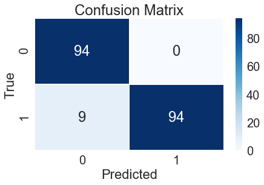

```
^^^^^^^^^^^^^^^^^^^^^^^^^^^^^^^^^^^^^^^^^^^^^^^^^^^^^^^^^^^^^^^^^^^^^^^^^^^^^^



------------------------------------------------------------------------------
Using classfier KNeighborsClassifier :

Confusion Matrix Scores:
             precision    recall  f1-score   support

     Normal       0.91      0.97      0.94        94
      Fraud       0.97      0.91      0.94       103

avg / total       0.94      0.94      0.94       197



Apply the best parameter to the test set and the result is:
```

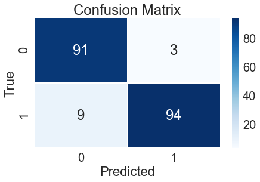

```
^^^^^^^^^^^^^^^^^^^^^^^^^^^^^^^^^^^^^^^^^^^^^^^^^^^^^^^^^^^^^^^^^^^^^^^^^^^^^^
```

# 5. Part 4: Boosting

Back to top

## 5.a) Adaboosting

An AdaBoost classifier is a meta-estimator that begins by fitting a classifier on the original dataset and then fits additional copies of the classifier on the same dataset but where the weights of incorrectly classified instances are adjusted such that subsequent classifiers focus more on difficult cases.

Here i use 3 different estimators applying to Adaboosting with different learning rates.

```
###################################################################################################################
Using classifier ***** DecisionTreeClassifier *****
--------------------------------------------------------------------
For learning rate is 0.01
[[91  3]
 [11 92]]
Recall score is 0.893203883495

--------------------------------------------------------------------
For learning rate is 0.1
[[93  1]
 [ 9 94]]
Recall score is 0.912621359223

--------------------------------------------------------------------
For learning rate is 0.2
[[93  1]
 [ 9 94]]
Recall score is 0.912621359223

--------------------------------------------------------------------
For learning rate is 0.5
[[90  4]
 [ 8 95]]
Recall score is 0.922330097087

--------------------------------------------------------------------
For learning rate is 1
[[87  7]
 [ 8 95]]
Recall score is 0.922330097087

--------------------------------------------------------------------
For learning rate is 2
[[17 77]
 [96  7]]
Recall score is 0.0679611650485
```

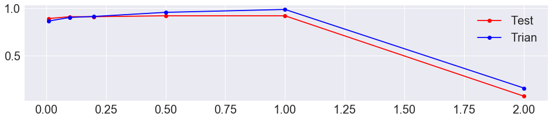

```
###################################################################################################################
Using classifier ***** LogisticRegression *****
--------------------------------------------------------------------
For learning rate is 0.01
[[94  0]
 [11 92]]
Recall score is 0.893203883495

--------------------------------------------------------------------
For learning rate is 0.1
[[94  0]
 [10 93]]
Recall score is 0.902912621359

--------------------------------------------------------------------
For learning rate is 0.2
[[93  1]
 [ 9 94]]
Recall score is 0.912621359223

--------------------------------------------------------------------
For learning rate is 0.5
[[92  2]
 [ 9 94]]
Recall score is 0.912621359223

--------------------------------------------------------------------
For learning rate is 1
[[91  3]
 [ 9 94]]
Recall score is 0.912621359223

--------------------------------------------------------------------
For learning rate is 2
[[90  4]
 [ 9 94]]
Recall score is 0.912621359223
```

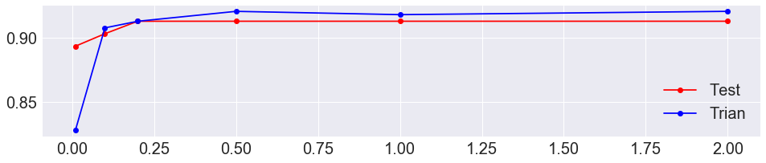

```
###################################################################################################################
Using classifier ***** GaussianNB *****
--------------------------------------------------------------------
For learning rate is 0.01
[[92  2]
 [10 93]]
Recall score is 0.902912621359

--------------------------------------------------------------------
For learning rate is 0.1
[[90  4]
 [10 93]]
Recall score is 0.902912621359

--------------------------------------------------------------------
For learning rate is 0.2
[[85  9]
 [55 48]]
Recall score is 0.466019417476

--------------------------------------------------------------------
For learning rate is 0.5
[[63 31]
 [ 5 98]]
Recall score is 0.95145631068

--------------------------------------------------------------------
For learning rate is 1
[[92  2]
 [85 18]]
Recall score is 0.174757281553

--------------------------------------------------------------------
For learning rate is 2
[[ 35  59]
 [  3 100]]
Recall score is 0.970873786408
```

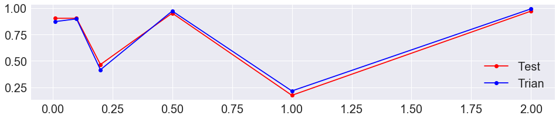

## 5.b) Gradient boosting

```
--------------------------------------------------------------------
For learning rate is 0.01
[[92  2]
 [ 9 94]]
Recall score is 0.912621359223

--------------------------------------------------------------------
For learning rate is 0.1
[[92  2]
 [ 8 95]]
Recall score is 0.922330097087

--------------------------------------------------------------------
For learning rate is 0.2
[[91  3]
 [ 8 95]]
Recall score is 0.922330097087

--------------------------------------------------------------------
For learning rate is 0.5
[[90  4]
 [ 7 96]]
Recall score is 0.932038834951

--------------------------------------------------------------------
For learning rate is 1
[[88  6]
 [ 8 95]]
Recall score is 0.922330097087

--------------------------------------------------------------------
For learning rate is 2
[[84 10]
 [10 93]]
Recall score is 0.902912621359
```

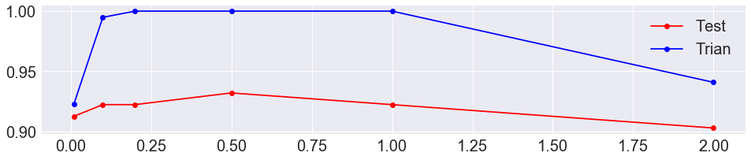

## 5.c) Test models using entire data

Back to top  
Here is applying models to whole dataset to its performance.  
Even though i used all fraud transcations to build our model, the result may be not reliable. However, it is helpful to see it precision score. Additionally, some normal transcations may be similar to fraud transcations, I want to see its recall score based on this concern.

### Indivisual Estimator ---- Logistic Regression

The numbers in confusion matrix in graph indicate the percentage of the total observations.

```
Overall accuracy is 96.5770%
Recall score is 0.920732%
Confusion Matrix:
[[274605   9710]
 [    39    453]]
Apply the best parameter to the test set and the result is:
```

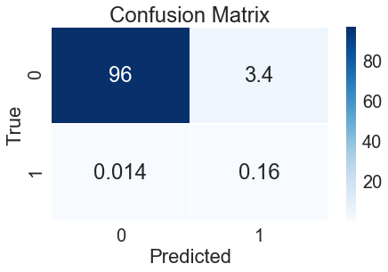

### Ensemble

```
Overall accuracy is 97.5085%
Recall score is 0.955285%
Confusion Matrix:
[[277241   7074]
 [    22    470]]
Apply the best parameter to the test set and the result is:
```

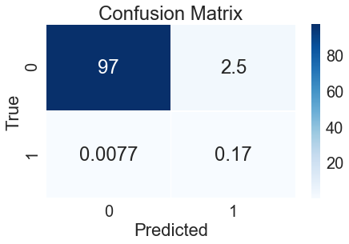

### Adaboost

[output not shown]

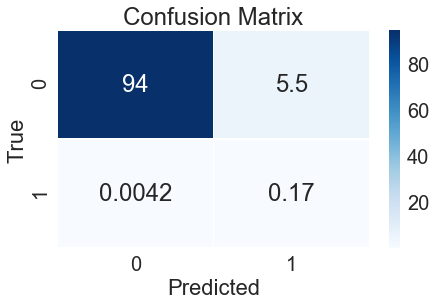

### Random Forest

```
Overall accuracy is 97.6454%
Recall score is 0.977642%
Confusion Matrix:
[[277620   6695]
 [    11    481]]
Apply the best parameter to the test set and the result is:
```

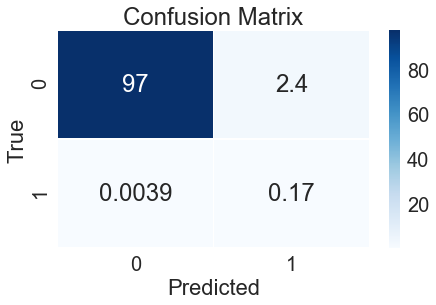

### Bagging

```
Overall accuracy is 96.1353%
Recall score is 0.979675%
Confusion Matrix:
[[273318  10997]
 [    10    482]]
Apply the best parameter to the test set and the result is:
```

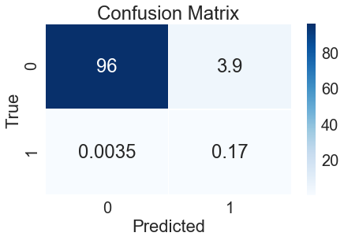

### Gradient Boosting

```
Overall accuracy is 96.3010%
Recall score is 0.983740%
Confusion Matrix:
[[273788  10527]
 [     8    484]]
Apply the best parameter to the test set and the result is:
```

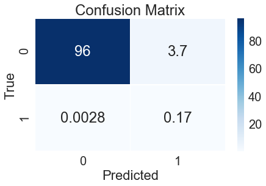

### Result

I see there the Gradient Boosting has the best recall score of 98%. The random forest has a bit lower score but with a higher precision score.  
There is a trade-off between recall and precision, so it has to choose wheather to strictly persue recall score or with some balance of precision.

# 6. Effort Table

Back to top

| Members | Contribution |
| --- | --- |
| Dong Liwu | 100% |